# Posterior Analysis

## Introduction

- Now that we know how to find posterior distributions, we will discuss how to use them to make inference.
- Here are the packages we need today:

```r
library(bayesrules)
library(tidyverse)
library(rstan)
library(bayesplot)
library(broom.mixed)
library(janitor)
data("moma_sample")
```

## Working Example

- Imagine you find yourself standing at the Museum of Modern Art (MoMA) in New York City, captivated by the artwork in front of you.
  - What are the chances that this modern artist is Gen X or even younger, i.e., born in 1965 or later?
- Let $\pi$ denote the proportion of artists represented in major U.S. modern art museums that are Gen X or younger.
  - Let’s let the Beta(4,6) prior model for $\pi$ reflect our prior assumption that major modern art museums disproportionately display artists born before 1965, i.e., $\pi$ most likely falls below 0.5.
  - Rationale: “modern art” dates back to the 1880s and it can take a while to gain recognition as an artist.

## Working Example

- The Beta(4,6) prior model for $\pi$:

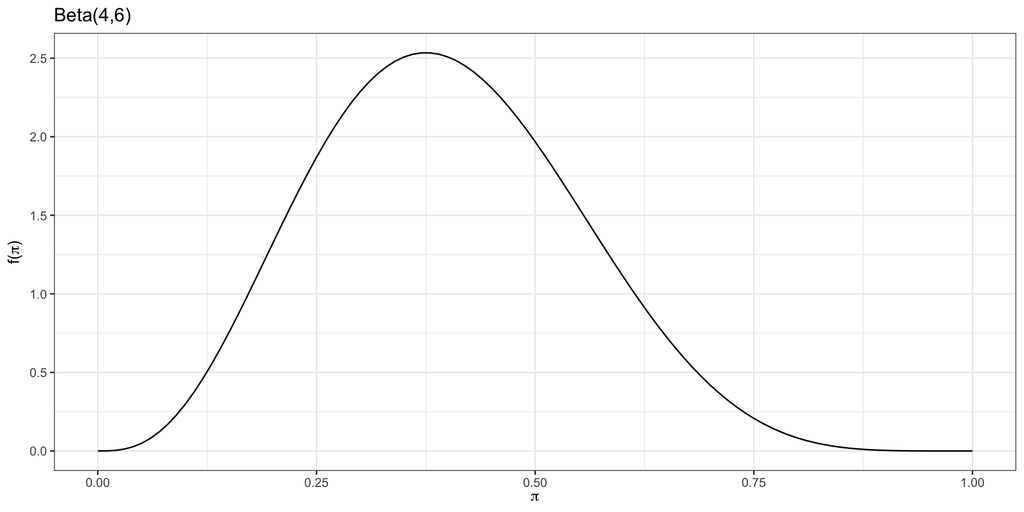

## Working Example

- Let’s consider the following dataset:

```r
head(moma_sample)
```

| artist | country | birth | death | alive | genx | gender | count | year_acquired_min | year_acquired_max |
| --- | --- | --- | --- | --- | --- | --- | --- | --- | --- |
| Ad Gerritsen | dutch | 1940 | 2015 | FALSE | FALSE | male | 1 | 1981 | 1981 |
| Kirstine Roepstorff | danish | 1972 | NA | TRUE | TRUE | female | 3 | 2005 | 2005 |
| Lisa Baumgardner | american | 1958 | 2015 | FALSE | FALSE | female | 2 | 2016 | 2016 |
| David Bates | american | 1952 | NA | TRUE | FALSE | male | 1 | 2001 | 2001 |
| Simon Levy | american | 1946 | NA | TRUE | FALSE | male | 1 | 2012 | 2012 |
| Pierre Mercure | canadian | 1927 | 1966 | FALSE | FALSE | male | 8 | 2008 | 2008 |

## Working Example

- Counting the number of Generation X and younger,

```r
moma_sample %>%
  group_by(genx) %>%
  tally()
```

| genx | n |
| --- | --- |
| FALSE | 86 |
| TRUE | 14 |

## Working Example

- Our modeling is as follows,

$$\begin{align*}
Y|\pi &\sim \text{Bin}(100,\pi) \\
\pi &\sim \text{Beta}(4,6) \\
\pi | (Y = 14) &\sim \text{Beta(18,92)}
\end{align*}$$

| model | alpha | beta | mean | mode | var | sd |
| --- | --- | --- | --- | --- | --- | --- |
| prior | 4 | 6 | 0.4000000 | 0.3750000 | 0.0218182 | 0.1477098 |
| posterior | 18 | 92 | 0.1636364 | 0.1574074 | 0.0012330 | 0.0351137 |

## Working Example

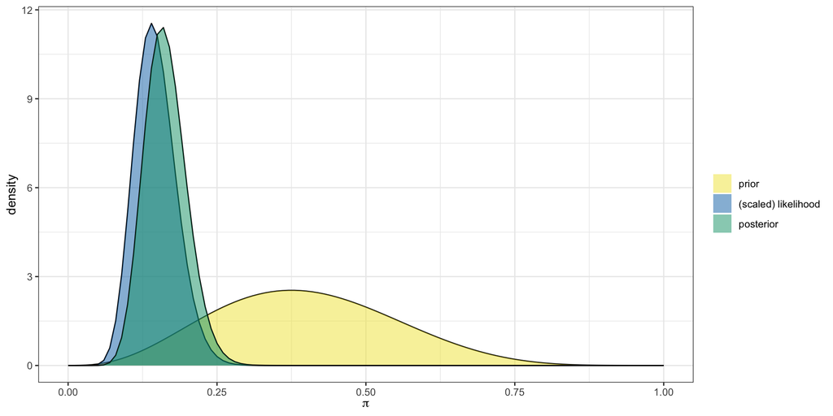

## Working Example

- There are three common tasks in posterior analysis:
  - estimation,
  - hypothesis testing, and
  - prediction.
- For example,
  - What’s our estimate of $\pi$?
  - Does our model support the claim that fewer than 20% of museum artists are Gen X or younger?
  - If we sample 20 more museum artists, how many do we predict will be Gen X or younger?

## Posterior Estimation

- We can construct **posterior credible intervals**.
  - A posterior credible interval (CI) provides a range of posterior plausible values of $\theta$, and thus a summary of both posterior central tendency and variability.
  - A middle 95% CI is constructed by the 2.5th and 97.5th posterior percentiles,
    $$\left( \theta_{0.025}, \theta_{0.975} \right),$$
    and there is a 95% posterior probability that $\theta$ is in this range,

$$P\left[ \theta \in (\theta_{0.025}, \theta_{0.975})|Y=y \right] = \int_{\theta_{0.025}}^{\theta_{0.975}} f(\theta|y) d\theta = 0.95$$

## Posterior Estimation

- Recall the Beta(18, 92) posterior model for $\pi$, the proportion of modern art museum artists that are Gen X or younger.

```r
qbeta(c(0.025, 0.975), 18, 92) # 95% CI
```

```
[1] 0.1009084 0.2379286
```

- There is a 95% posterior probability that somewhere between 10% and 24% of museum artists are Gen X or younger.

## Posterior Estimation

- Recall the Beta(18, 92) posterior model for $\pi$, the proportion of modern art museum artists that are Gen X or younger.

```r
qbeta(c(0.25, 0.75), 18, 92) # 50% CI
```

```
[1] 0.1388414 0.1862197
```

- There is a 50% posterior probability that somewhere between 14% and 19% of museum artists are Gen X or younger.

## Posterior Estimation

- 95% is a common choice, however, note that it is somewhat arbitrary and used because of decades of tradition.

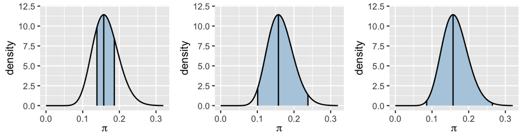

- There is no one right credible interval.
  - It will just depend on the context of the analysis.

## Posterior Hypothesis Testing

- Suppose we read an article claiming that fewer than 20% of museum artists are Gen X or younger.

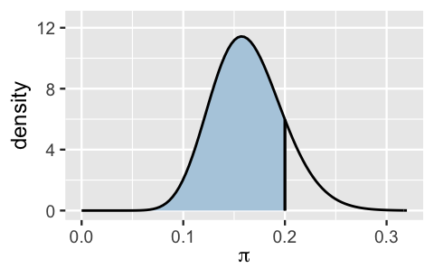

- How plausible is it that $\pi < 0.2$?

$$P\left[ \pi < 0.2 | Y = 14 \right] = \int_0^{0.2} f(\pi|y = 14) d\pi$$

## Posterior Hypothesis Testing

- Posterior Probability

$$P\left[ \pi < 0.2 | Y = 14 \right] = \int_0^{0.2} f(\pi|y = 14) d\pi$$

- We can find this probability by using the `pbeta()` function:

```r
pbeta(0.20, 18, 92)
```

## Posterior Hypothesis Testing

- We can find this probability by using the `pbeta()` function:

```r
pbeta(0.20, 18, 92)
```

```
[1] 0.8489856
```

- Thus,

$$P\left[ \pi < 0.2 | Y = 14 \right] = 0.849$$

- There is approximately an 84.9% posterior chance that Gen Xers account for fewer than 20% of modern art museum artists.

## Posterior Hypothesis Testing

- Prior Probability

$$P\left[ \pi < 0.2 \right] = \int_0^{0.2} f(\pi) d\pi$$

- We can find this probability by using the `pbeta()` function:

```r
pbeta(0.20, 4, 6)
```

## Posterior Hypothesis Testing

- We can find this probability by using the `pbeta()` function:

```r
pbeta(0.20, 4, 6)
```

```
[1] 0.08564173
```

- Thus,

$$P\left[ \pi < 0.2 \right] = 0.086$$

- There is approximately an 8.6% prior chance that Gen Xers account for fewer than 20% of modern art museum artists.

## Posterior Hypothesis Testing

- We can create a table of information we will use to make inferences:

| Hypotheses | Prior Probability | Posterior Probability |
| --- | --- | --- |
| $H_0: \pi \ge 0.2$ | $P[H_0] = 0.914$ | $P[H_0 \| Y= 14] = 0.151$ |
| $H_1: \pi < 0.2$ | $P[H_1] = 0.086$ | $P[H_1 \| Y = 14] = 0.849$ |

## Posterior Hypothesis Testing

- Let’s find the posterior odds in favor of $H_1$:

| Hypotheses | Prior Probability | Posterior Probability |
| --- | --- | --- |
| $H_0: \pi \ge 0.2$ | $P[H_0] = 0.914$ | $P[H_0 \| Y= 14] = 0.151$ |
| $H_1: \pi < 0.2$ | $P[H_1] = 0.086$ | $P[H_1 \| Y = 14] = 0.849$ |

$$\begin{align*}
\text{posterior odds} &= \frac{P\left[ H_1 | Y = 14 \right]}{P\left[ H_0 | Y = 14 \right]} \\
&= \frac{0.849}{0.151} \\
&\approx 5.62
\end{align*}$$

- Our posterior assessment, after considering data collected, suggests that $\pi$ is 5.62 times more likely to be *below* 0.2 rather than being *above* 0.2.

## Posterior Hypothesis Testing

- Let’s find the prior odds in favor of $H_1$:

| Hypotheses | Prior Probability | Posterior Probability |
| --- | --- | --- |
| $H_0: \pi \ge 0.2$ | $P[H_0] = 0.914$ | $P[H_0 \| Y= 14] = 0.151$ |
| $H_1: \pi < 0.2$ | $P[H_1] = 0.086$ | $P[H_1 \| Y = 14] = 0.849$ |

$$\begin{align*}
\text{prior odds} &= \frac{P\left[ H_1 \right]}{P\left[ H_0 \right]} \\
&= \frac{0.086}{0.914} \\
&\approx 0.093
\end{align*}$$

- Our prior assessment, before considering the data collected, suggests that $\pi$ is 0.093 times more likely to be *below* 0.2 rather than being *above* 0.2.

## Posterior Hypothesis Testing

- Bayes Factor
  - When we are comparing two competing hypotheses, $H_0$ vs. $H_1$, the Bayes Factor is an odds ratio for $H_1$.
  - i.e., the Bayes Factor as a measure of evidence in favor of $H_1$.

$$\text{Bayes Factor} = \frac{\text{posterior odds}}{\text{prior odds}} = \frac{P\left[H_1 | Y\right] / P\left[H_0 | Y\right]}{P\left[H_1\right] / P\left[H_0\right]}$$

- This will be our alternative to the *p*-value.

## Posterior Hypothesis Testing

- Bayes Factor

$$\text{Bayes Factor} = \frac{\text{posterior odds}}{\text{prior odds}} = \frac{P\left[H_1 | Y\right] / P\left[H_0 | Y\right]}{P\left[H_1\right] / P\left[H_0\right]}$$

- We will compare the BF to 1.
  - BF = 1: The plausibility of $H_1$ did not change in light of the observed data.
  - BF > 1: The plausibility of $H_1$ increased in light of the observed data.
    - The greater the Bayes Factor, the more convincing the evidence for $H_1$.
  - BF < 1: The plausibilty of $H_1$ decreased in light of the observed data.

## Posterior Hypothesis Testing

- Let’s now find the Bayes Factor:

| Hypotheses | Prior Probability | Posterior Probability |
| --- | --- | --- |
| $H_0: \pi \ge 0.2$ | $P[H_0] = 0.914$ | $P[H_0 \| Y= 14] = 0.151$ |
| $H_1: \pi < 0.2$ | $P[H_1] = 0.086$ | $P[H_1 \| Y = 14] = 0.849$ |

$$\begin{align*}
\text{Bayes Factor} &= \frac{\text{posterior odds}}{\text{prior odds}} = \frac{P\left[H_1 | Y\right] / P\left[H_0 | Y\right]}{P\left[H_1\right] / P\left[H_0\right]} \\
&= \frac{5.62}{0.09} \\
&\approx 62.44
\end{align*}$$

## Posterior Hypothesis Testing

- Let’s now find the Bayes Factor:

| Hypotheses | Prior Probability | Posterior Probability |
| --- | --- | --- |
| $H_0: \pi \ge 0.2$ | $P[H_0] = 0.914$ | $P[H_0 \| Y= 14] = 0.151$ |
| $H_1: \pi < 0.2$ | $P[H_1] = 0.086$ | $P[H_1 \| Y = 14] = 0.849$ |

```r
prior_odds <- pbeta(0.20, 4, 6)/(1-pbeta(0.20, 4, 6))
post_odds <- pbeta(0.20, 18, 92)/(1-pbeta(0.20, 18, 92))
(BF <- post_odds/prior_odds)
```

```
[1] 60.02232
```

## Posterior Hypothesis Testing

- It’s time to draw a conclusion!
  - Posterior probability: 0.85
  - Bayes factor: 60
- We have fairly convincing evidence in factor of the claim that fewer than 20% of artists at major modern art museums are Gen X or younger.
- This gives us more information - we have a holistic measure of the level of uncertainty about the claim.
  - This should help us inform our next steps.

## Posterior Hypothesis Testing

- We now want to test whether or not 30% of major museum artists are Gen X or younger.

$$\begin{align*}
H_0&: \ \pi = 0.3 \\
H_1&: \ \pi \ne 0.3
\end{align*}$$

- Why is this an issue?

## Posterior Hypothesis Testing

- We now want to test whether or not 30% of major museum artists are Gen X or younger.

$$\begin{align*}
H_0&: \ \pi = 0.3 \\
H_1&: \ \pi \ne 0.3
\end{align*}$$

- Why is this an issue? The posterior probability of a point hypothesis is always 0!

$$P\left[ \pi =0.3 | Y = 14 \right] = \int_{0.3}^{0.3} f(\pi|y = 14) d\pi = 0$$

## Posterior Hypothesis Testing

- The posterior probability of a point hypothesis is always 0!

$$P\left[ \pi =0.3 | Y = 14 \right] = \int_{0.3}^{0.3} f(\pi|y = 14) d\pi = 0$$

- …. meaning:

$$\text{posterior odds} = \frac{P\left[ H_1 | Y = 14 \right]}{P\left[ H_0 | Y = 14 \right]} = \frac{1}{0}$$

## Posterior Hypothesis Testing

- Welp.
- Let’s think about the 95% posterior credible interval for $\pi$: (0.10, 0.24).
  - Do we think that 0.3 is a plausible value?

## Posterior Hypothesis Testing

- Let’s reframe our hypotheses:

$$\begin{align*}
H_0&: \ \pi \in (0.25, 0.35) \\
H_1&: \ \pi \not\in (0.25, 0.35)
\end{align*}$$

- Now, we can more rigorously claim belief in $H_1$.
  - The entire hypothesized range is above the 95% CI.
- This also allows us a way to construct our hypothesis test with posterior probability and Bayes Factor.

## Posterior Prediction

- In addition to estimating the posterior and using the posterior distribution for hypothesis testing, we may be interested in predicting the outcome in a new dataset.
- Suppose we get our hands on data for 20 more artworks displayed at the museum.
- Based on the posterior understanding of $\pi$ that we’ve developed throughout this chapter, what number would you predict are done by artists that are Gen X or younger?

## Posterior Prediction

- Suppose we get our hands on data for 20 more artworks displayed at the museum.
- Based on the posterior understanding of $\pi$ that we’ve developed throughout this chapter, what number would you predict are done by artists that are Gen X or younger?
  - Logical response:
    - posterior guess was 16%
    - $n = 20$
    - $n \hat{\pi} = 20(0.16) = 3.2$

## Posterior Prediction

- Suppose we get our hands on data for 20 more artworks displayed at the museum. What number would you predict are done by artists that are Gen X or younger?
  - Two sources of variability in prediction:
    - Sampling variability: we do not expect $n \hat{\pi}$ to be an integer.
    - Posterior variability in $\pi$: we know that 0.16 is not the only plausible $\pi$.
      - 95% credible interval for $\pi$: $(0.10, 0.24)$
      - What do we expect to see under each possible $\pi$?

## Posterior Prediction

- Let’s look at combining the sampling variability in our new $Y$ and posterior variability in $\pi$.
  - Let $Y' = y'$ be the (unknown) number of the 20 new artwork that are done by Gen X or younger artists.
    - $y' \in \{0, 1, ..., 20\}$.
  - Conditioned on $\pi$, the sampling variability in $Y'$ can be modeled

$$Y'|\pi \sim \text{Bin}(20, \pi)$$

$$f(y'|\pi) = P[Y' = y'|\pi] = {20\choose{y'}} \pi^{y'} (1-\pi)^{20-y'}$$

## Posterior Prediction

- We can weight $f(y'|\pi)$ by the posterior pdf, $f(\pi|y=14)$.
  - This captures the chance of observing $Y' = y'$ Gen Xers for a given $\pi$
  - At the same time, this accounts for the posterior plausibility of $\pi$.

$$f(y'|\pi) f(\pi|y=14)$$

## Posterior Prediction

- This leads us to the posterior predictive model of $Y'$.

$$f(y'|y) = \int f(y'|\pi) f(\pi|y) \ d \pi$$

- The overall chance of observing $Y' = y'$ weights the chance of observing this outcome under *any* possible $\pi$ by the posterior plausibility of $\pi$.
  - Chance of observing this outcome under any $\pi$: $f(y'|\pi)$.
  - Posterior plausibility of $\pi$: $f(\pi|y)$.

## Posterior Prediction

```r
# STEP 1: DEFINE the model
art_model <- "
  data {
    int<lower = 0, upper = 100> Y;
  }
  parameters {
    real<lower = 0, upper = 1> pi;
  }
  model {
    Y ~ binomial(100, pi);
    pi ~ beta(4, 6);
  }
"
```

## Posterior Prediction

```r
# STEP 2: SIMULATE the posterior
art_sim <- stan(model_code = art_model,
                data = list(Y = 14),
                chains = 4,
                iter = 5000*2,
                seed = 84735)
```

## Posterior Prediction

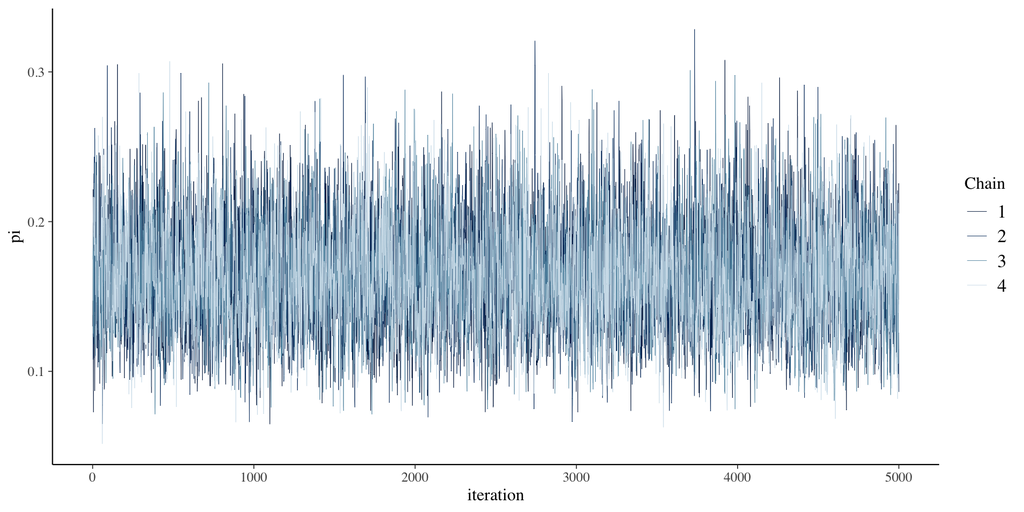

```r
# Parallel trace plot
mcmc_trace(art_sim, pars = "pi", size = 0.5) + xlab("iteration")
```

## Posterior Prediction

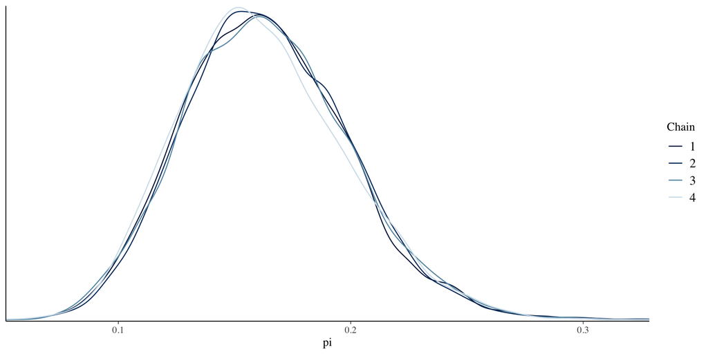

```r
# Density plot
mcmc_dens_overlay(art_sim, pars = "pi")
```

## Posterior Prediction

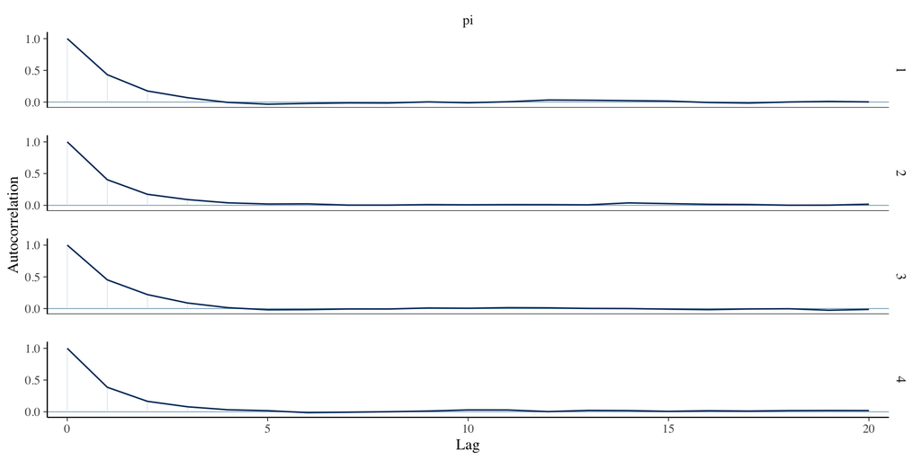

```r
# Autocorrelation plot
mcmc_acf(art_sim, pars = "pi")
```

## Posterior Prediction

- As we saw previously, the posterior was Beta(18, 92).
- We will use the `tidy()` function from the `broom.mixed` package.

```r
library(broom.mixed)
tidy(art_sim, conf.int = TRUE, conf.level = 0.95)
```

| term | estimate | std.error | conf.low | conf.high |
| --- | --- | --- | --- | --- |
| pi | 0.1635453 | 0.0353673 | 0.1000882 | 0.2391218 |

- The approximate middle 95% CI for $\pi$ is (0.100, 0.239).
- Our approximation of the actual posterior median is 0.162.

## Posterior Prediction

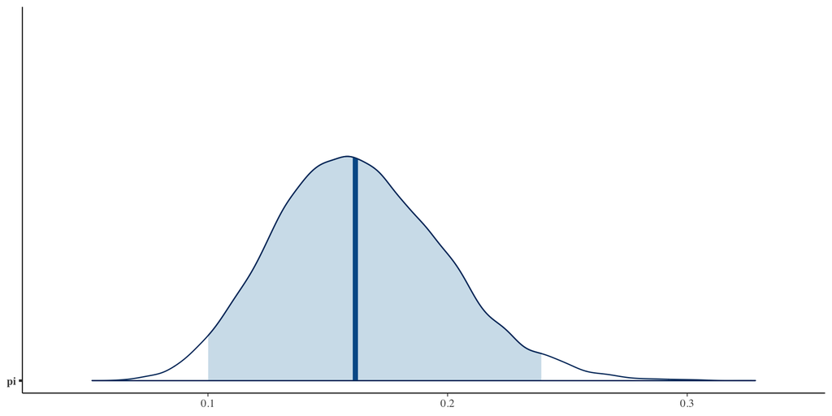

```r
mcmc_areas(art_sim, pars = "pi", prob = 0.95)
```

## Posterior Simulation

- Unfortunately, `tidy()` does not give everything we may be interested in.
  - We can save the Markov chain values to a dataset and analyze.

```r
# Store the 4 chains in 1 data frame
art_chains_df <- as.data.frame(art_sim, pars = "lp__", include = FALSE)
dim(art_chains_df)
```

```
[1] 20000     1
```

```r
head(art_chains_df, n=3)
```

| pi |
| --- |
| 0.1300701 |
| 0.1755285 |
| 0.2214175 |

## Posterior Simulation

- We can then summarize the Markov chain values,

```r
art_chains_df %>%
  summarize(post_mean = mean(pi),
            post_median = median(pi),
            post_mode = sample_mode(pi),
            lower_95 = quantile(pi, 0.025),
            upper_95 = quantile(pi, 0.975))
```

| post_mean | post_median | post_mode | lower_95 | upper_95 |
| --- | --- | --- | --- | --- |
| 0.1635453 | 0.1615222 | 0.1583033 | 0.1000882 | 0.2391218 |

- We have reproduced/verified the results from `tidy()` (and then some!)

## Posterior Simulation

- Now that we have saved the Markov chain values, we can use them to answer questions about the data.
- Recall, we were interested in testing the claim that fewer than 20% of major museum artists are Gen X.

```r
art_chains_df %>%
  mutate(exceeds = pi < 0.20) %>%
  tabyl(exceeds)
```

| exceeds | n | percent |
| --- | --- | --- |
| FALSE | 3061 | 0.15305 |
| TRUE | 16939 | 0.84695 |

- By the posterior, there is an 84.6% chance that Gen X artist representation is under 20%.

## Posterior Simulation

- Let us compare the results between using conjugate family knowledge and MCMC.

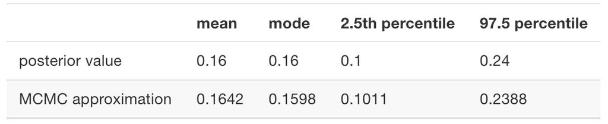